# Module 08: Spatial Social Science

## 2.2 Your First Map

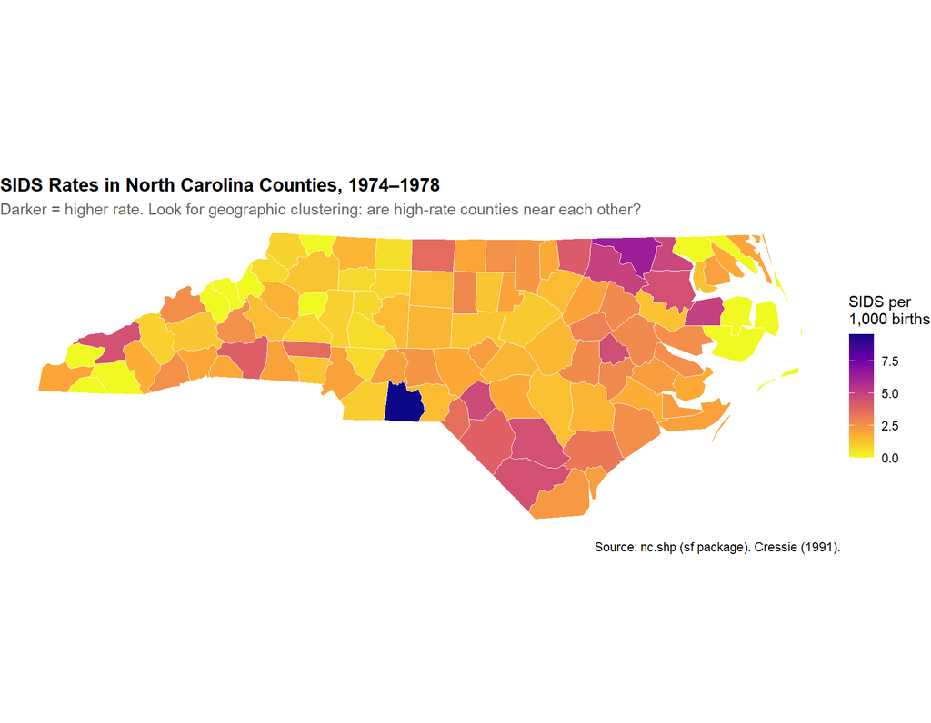

```r
# Project to NAD83 / NC State Plane for better visual proportions
nc_proj <- st_transform(nc, 32119)

ggplot(nc_proj) +
  geom_sf(aes(fill=sids_rate74), colour="white", linewidth=0.3) +
  scale_fill_viridis_c(
    option    = "plasma",
    name      = "SIDS per\n1,000 births",
    direction = -1,
    na.value  = "grey80"
  ) +
  labs(
    title    = "SIDS Rates in North Carolina Counties, 1974–1978",
    subtitle = paste("Darker = higher rate. Look for geographic clustering:",
                     "are high-rate counties near each other?"),
    caption  = "Source: nc.shp (sf package). Cressie (1991)."
  ) +
  theme_void() +
  theme(plot.title=element_text(face="bold"),
        plot.subtitle=element_text(colour="grey40"))
```

**Reading a choropleth map:** Scan for areas where similar colours cluster together — this visual pattern is spatial autocorrelation. If the map looks like a random patchwork (salt-and-pepper), there is little spatial structure. If you see contiguous regions of similar shade, there is clustering. The question is whether what you see is statistically significant or could be chance.

## 2.3 Describing the Distribution

```r
cat("=== DESCRIPTIVE STATISTICS ===\n\n")
```

```
## === DESCRIPTIVE STATISTICS ===
```

```r
cat("SIDS rate 1974-78:\n")
```

```
## SIDS rate 1974-78:
```

```r
cat("  Mean:", round(mean(nc$sids_rate74, na.rm=TRUE), 3), "per 1,000 births\n")
```

```
##   Mean: 2.046 per 1,000 births
```

```r
cat("  SD:  ", round(sd(nc$sids_rate74, na.rm=TRUE), 3), "\n")
```

```
##   SD:   1.573
```

```r
cat("  Min: ", round(min(nc$sids_rate74, na.rm=TRUE), 3),
    "  Max:", round(max(nc$sids_rate74, na.rm=TRUE), 3), "\n")
```

```
##   Min:  0   Max: 9.554
```

```r
cat("  Counties with rate = 0:", sum(nc$sids_rate74 == 0, na.rm=TRUE), "\n\n")
```

```
##   Counties with rate = 0: 13
```

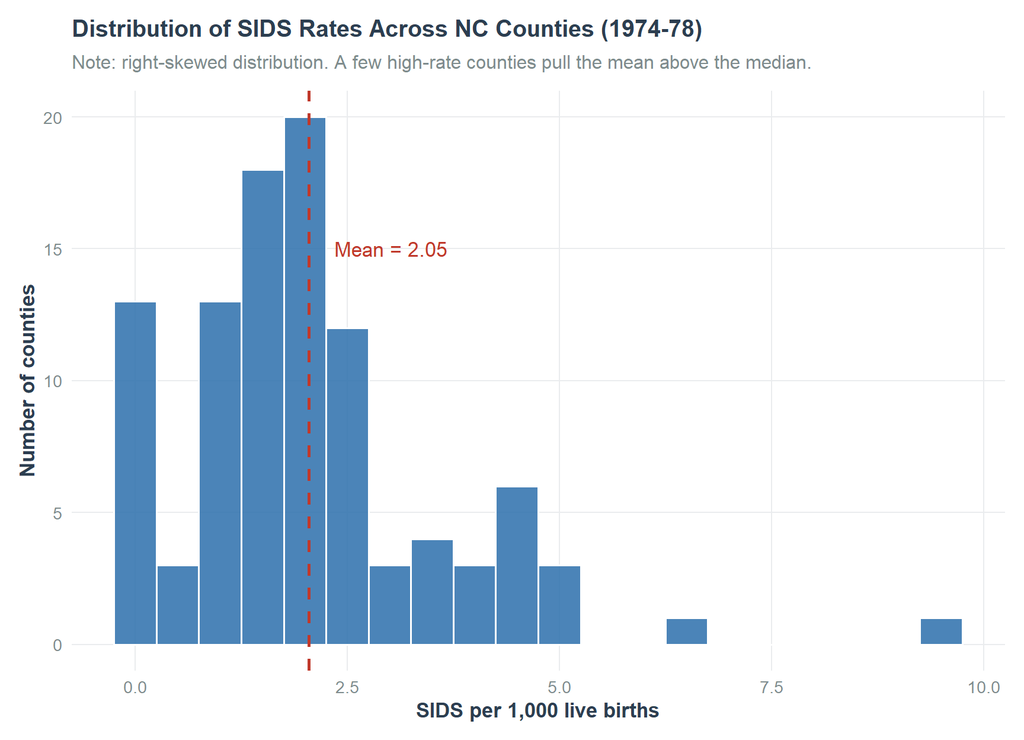

```r
# Distribution plot
nc |> st_drop_geometry() |>
  ggplot(aes(x=sids_rate74)) +
  geom_histogram(binwidth=0.5, fill="#2C6FAC", colour="white", alpha=0.85) +
  geom_vline(aes(xintercept=mean(sids_rate74, na.rm=TRUE)),
             colour="#C0392B", linetype="dashed", linewidth=1) +
  annotate("text",
           x=mean(nc$sids_rate74, na.rm=TRUE)+0.3,
           y=15,
           label=paste0("Mean = ",
             round(mean(nc$sids_rate74, na.rm=TRUE),2)),
           hjust=0, colour="#C0392B") +
  labs(title="Distribution of SIDS Rates Across NC Counties (1974-78)",
       x="SIDS per 1,000 live births", y="Number of counties",
       subtitle="Note: right-skewed distribution. A few high-rate counties pull the mean above the median.")
```

## 2.4 Bivariate Relationship Before Spatial Analysis

Before any spatial modelling, understand the basic bivariate relationship:

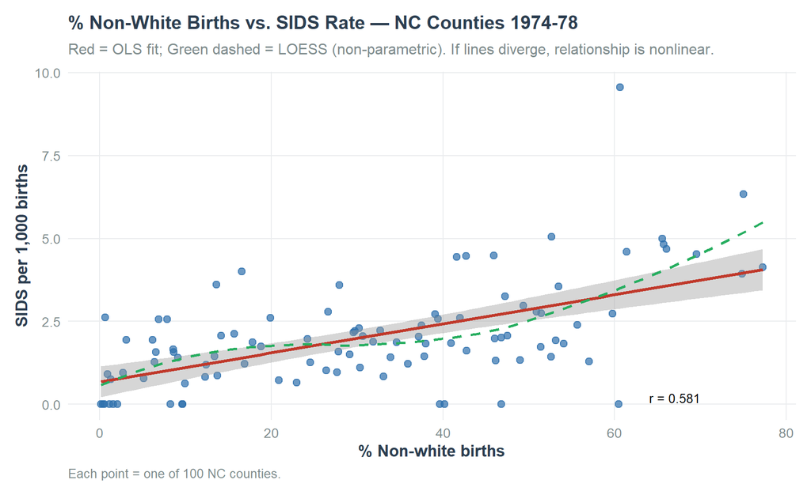

```r
# Does % non-white births predict SIDS rates?
cor_val <- cor(nc$sids_rate74, nc$nw_pct74, use="complete.obs")

ggplot(nc |> st_drop_geometry(),
       aes(x=nw_pct74, y=sids_rate74)) +
  geom_point(alpha=0.7, colour="#2C6FAC", size=2.5) +
  geom_smooth(method="lm", colour="#C0392B", se=TRUE, linewidth=1.2) +
  geom_smooth(method="loess", colour="#27AE60", se=FALSE,
              linetype="dashed", linewidth=1) +
  annotate("text", x=70, y=0.2, hjust=1, size=3.5,
           label=paste0("r = ", round(cor_val, 3))) +
  labs(
    title    = "% Non-White Births vs. SIDS Rate — NC Counties 1974-78",
    subtitle = "Red = OLS fit; Green dashed = LOESS (non-parametric). If lines diverge, relationship is nonlinear.",
    x="% Non-white births",
    y="SIDS per 1,000 births",
    caption  = "Each point = one of 100 NC counties."
  )
```

```r
cat("Pearson correlation: r =", round(cor_val, 3), "\n")
```

```
## Pearson correlation: r = 0.581
```

```r
cat("Interpretation: ", abs(round(cor_val,3)),
    ifelse(abs(cor_val) > 0.5, "(moderate to strong)", "(weak to moderate)"),
    "positive association.\n")
```

```
## Interpretation:  0.581 (moderate to strong) positive association.
```

```r
cat("Higher % non-white births → higher SIDS rate.\n")
```

```
## Higher % non-white births → higher SIDS rate.
```

```r
cat("BUT: this could be confounded by poverty, healthcare access, etc.\n")
```

```
## BUT: this could be confounded by poverty, healthcare access, etc.
```

# 3 Part B: Measuring Spatial Autocorrelation

## 3.1 Spatial Weights Matrix

Before computing Moran’s I, you need to define what “nearby” means — the spatial weights matrix W. This is a substantive modelling choice, not just a technical step.

```r
library(spdep)

nc_sp   <- as(nc_proj, "Spatial")
nb_queen <- poly2nb(nc_sp, queen=TRUE)  # Queen contiguity: share any boundary point

cat("=== SPATIAL WEIGHTS (Queen Contiguity) ===\n\n")
```

```
## === SPATIAL WEIGHTS (Queen Contiguity) ===
```

```r
cat("Definition: Two counties are neighbours if they share any border point.\n\n")
```

```
## Definition: Two counties are neighbours if they share any border point.
```

```r
cat("Summary:\n")
```

```
## Summary:
```

```r
cat("  Counties:", length(nb_queen), "\n")
```

```
##   Counties: 100
```

```r
cat("  Average neighbours:", round(mean(card(nb_queen)), 2), "\n")
```

```
##   Average neighbours: 4.9
```

```r
cat("  Min neighbours:", min(card(nb_queen)),
    "(island county — few borders)\n")
```

```
##   Min neighbours: 2 (island county — few borders)
```

```r
cat("  Max neighbours:", max(card(nb_queen)), "\n\n")
```

```
##   Max neighbours: 9
```

```r
# Row-standardise: each county's neighbours' weights sum to 1
# Makes spatial lag = weighted average of neighbours' values
lw <- nb2listw(nb_queen, style="W", zero.policy=TRUE)

cat("Row-standardised weights applied.\n")
```

```
## Row-standardised weights applied.
```

```r
cat("Result: spatial lag of Y[i] = average Y across i's neighbours.\n")
```

```
## Result: spatial lag of Y[i] = average Y across i's neighbours.
```

**Neighbourhood definitions compared:**

| Type | Definition | When to Use |
| --- | --- | --- |
| Queen contiguity | Share any boundary point (edge or corner) | Default for county/census data |
| Rook contiguity | Share a boundary edge only (no corners) | When corners are unlikely to create real spillovers |
| k-nearest neighbours | K geographically closest units | When units vary greatly in size; ensures all have same number of neighbours |
| Distance-based | Units within d km are neighbours | When a specific spatial range is theoretically meaningful |
| Inverse distance | Weight decreases with distance | When proximity matters continuously, not just inside/outside a threshold |

## 3.2 Global Moran’s I

Moran’s I answers the question: overall, do similar values cluster together geographically?

$$I = \frac{N}{\sum_i \sum_j w_{ij}} \cdot
\frac{\sum_i \sum_j w_{ij}(y_i - \bar{y})(y_j - \bar{y})}{\sum_i (y_i -
\bar{y})^2}$$

In plain English: it measures whether a county’s deviation from the mean tends to match its neighbours’ deviations. Positive I = similar values cluster; negative I = dissimilar values cluster (chess-board pattern); I ≈ 0 = random spatial distribution.

```r
moran_result <- moran.mc(
  nc_proj$sids_rate74,
  listw       = lw,
  nsim        = 999,
  zero.policy = TRUE
)

cat("=== GLOBAL MORAN'S I — SIDS RATES 1974-78 ===\n\n")
```

```
## === GLOBAL MORAN'S I — SIDS RATES 1974-78 ===
```

```r
cat("Observed Moran's I:", round(moran_result$statistic, 4), "\n")
```

```
## Observed Moran's I: 0.2309
```

```r
cat("Expected I (random):  ", round(mean(moran_result$res), 4), "\n")
```

```
## Expected I (random):   -0.0127
```

```r
cat("p-value (permutation):", round(moran_result$p.value, 4), "\n")
```

```
## p-value (permutation): 0.001
```

```r
cat("N permutations:        999\n\n")
```

```
## N permutations:        999
```

```r
cat("INTERPRETATION:\n")
```

```
## INTERPRETATION:
```

```r
if (moran_result$p.value < 0.05 && moran_result$statistic > 0) {
  cat("→ Significant positive spatial autocorrelation (p <",
      round(moran_result$p.value, 3), ").\n")
  cat("→ High-rate counties cluster together; low-rate counties cluster together.\n")
  cat("→ The geographic pattern is NOT random — something drives this clustering.\n")
} else {
  cat("→ No significant spatial autocorrelation detected.\n")
  cat("→ SIDS rates appear randomly distributed across counties.\n")
}
```

```
## → Significant positive spatial autocorrelation (p < 0.001 ).
## → High-rate counties cluster together; low-rate counties cluster together.
## → The geographic pattern is NOT random — something drives this clustering.
```

[figure not shown]

```r
moran.plot(
  x           = nc_proj$sids_rate74,
  listw       = lw,
  xlab        = "SIDS rate (standardised)",
  ylab        = "Spatially lagged SIDS rate (neighbours' average, standardised)",
  main        = "Moran Scatterplot: SIDS Rates 1974-78",
  zero.policy = TRUE
)
abline(h=0, v=0, lty=2, col="grey60")
```

# 4 Part C: Local Clusters (LISA)

## 4.1 What LISA Tells You That Global Moran’s I Cannot

Global Moran’s I tells you *whether* clustering exists. LISA (Local Indicators of Spatial Association) tells you *where* it exists and what type.

```r
lmoran <- localmoran(
  nc_proj$sids_rate74,
  listw       = lw,
  zero.policy = TRUE
)

nc_lisa <- nc_proj |>
  mutate(
    local_I  = lmoran[,"Ii"],
    local_p  = p.adjust(lmoran[,"Pr(z != E(Ii))"], method = "BH"),  # BH correction
    z_rate   = as.numeric(scale(sids_rate74)),
    z_lag    = as.numeric(scale(lag.listw(lw, sids_rate74, zero.policy=TRUE))),
    lisa_type = case_when(
      local_p > 0.05                   ~ "Not significant",
      z_rate > 0 & z_lag > 0           ~ "High-High (hot spot)",
      z_rate < 0 & z_lag < 0           ~ "Low-Low  (cold spot)",
      z_rate > 0 & z_lag < 0           ~ "High-Low  (outlier)",
      z_rate < 0 & z_lag > 0           ~ "Low-High  (outlier)",
      TRUE                             ~ "Not significant"
    ),
    lisa_type = factor(lisa_type,
      levels=c("High-High (hot spot)","Low-Low  (cold spot)",
               "High-Low  (outlier)","Low-High  (outlier)","Not significant"))
  )

cat("=== LISA CLUSTER TYPE DISTRIBUTION ===\n")
```

```
## === LISA CLUSTER TYPE DISTRIBUTION ===
```

```r
print(table(nc_lisa$lisa_type))
```

```
##
## High-High (hot spot) Low-Low  (cold spot)  High-Low  (outlier)
##                    2                    0                    0
##  Low-High  (outlier)      Not significant
##                    1                   97
```

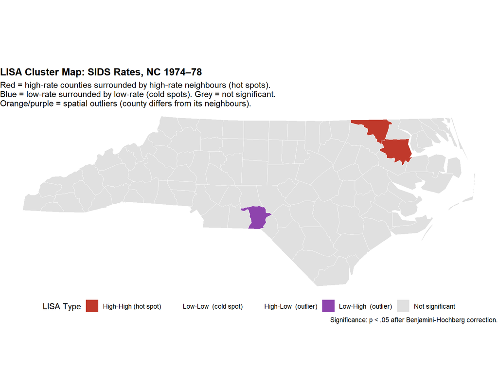

```r
ggplot(nc_lisa) +
  geom_sf(aes(fill=lisa_type), colour="white", linewidth=0.3) +
  scale_fill_manual(
    values = c(
      "High-High (hot spot)"  = "#C0392B",
      "Low-Low  (cold spot)"  = "#2C6FAC",
      "High-Low  (outlier)"   = "#E67E22",
      "Low-High  (outlier)"   = "#8E44AD",
      "Not significant"       = "grey88"
    ),
    name="LISA Type", drop=FALSE
  ) +
  labs(
    title    = "LISA Cluster Map: SIDS Rates, NC 1974–78",
    subtitle = paste(
      "Red = high-rate counties surrounded by high-rate neighbours (hot spots).",
      "\nBlue = low-rate surrounded by low-rate (cold spots). Grey = not significant.",
      "\nOrange/purple = spatial outliers (county differs from its neighbours)."
    ),
    caption  = "Significance: p < .05 after Benjamini-Hochberg correction."
  ) +
  theme_void() +
  theme(plot.title=element_text(face="bold"), legend.position="bottom")
```

**Reading the LISA map:** Each coloured county is part of a statistically significant spatial cluster. Red (High-High) counties are a public health concern — they form geographic concentrations of elevated SIDS risk. Blue (Low-Low) counties are in a geographic region of low risk. Purple and orange counties are anomalies — they do not fit the surrounding pattern and deserve investigation: are they data errors? Do they have unusual characteristics that set them apart from their neighbours?

# 5 Part D: Spatial Regression

## 5.1 Why OLS Fails with Spatial Data

If your outcome variable is spatially autocorrelated, the residuals from an OLS regression are almost certainly spatially autocorrelated too. This violates OLS’s independence assumption and has two consequences:

1. **Biased coefficients** — if the omitted spatially-clustered variable is a confounder
2. **Underestimated standard errors** — false precision; you reject H₀ too often

**The Lagrange Multiplier diagnostic tests** (from an OLS model) tell you whether the problem is in the outcome (spatial lag) or in the errors (spatial error):

```r
# First, fit a standard OLS baseline
ols_m <- lm(sids_rate74 ~ nw_pct74 + log(BIR74),
            data = nc_proj |> st_drop_geometry())

cat("=== OLS BASELINE MODEL ===\n")
```

```
## === OLS BASELINE MODEL ===
```

```r
summary(ols_m)
```

```
##
## Call:
## lm(formula = sids_rate74 ~ nw_pct74 + log(BIR74), data = st_drop_geometry(nc_proj))
##
## Residuals:
##     Min      1Q  Median      3Q     Max
## -3.0065 -0.7824 -0.2284  0.5419  6.2830
##
## Coefficients:
##              Estimate Std. Error t value Pr(>|t|)
## (Intercept) -0.802545   1.019250  -0.787    0.433
## nw_pct74     0.043470   0.006169   7.047 2.67e-10 ***
## log(BIR74)   0.195384   0.131058   1.491    0.139
## ---
## Signif. codes:  0 '***' 0.001 '**' 0.01 '*' 0.05 '.' 0.1 ' ' 1
##
## Residual standard error: 1.28 on 97 degrees of freedom
## Multiple R-squared:  0.3519, Adjusted R-squared:  0.3385
## F-statistic: 26.33 on 2 and 97 DF,  p-value: 7.343e-10
```

```r
lm_tests <- lm.LMtests(ols_m, listw=lw,
                         test=c("LMlag","LMerr","RLMlag","RLMerr"),
                         zero.policy=TRUE)

cat("\n=== LAGRANGE MULTIPLIER DIAGNOSTIC TESTS ===\n")
```

```
##
## === LAGRANGE MULTIPLIER DIAGNOSTIC TESTS ===
```

```r
cat("(Do OLS residuals show spatial autocorrelation?)\n\n")
```

```
## (Do OLS residuals show spatial autocorrelation?)
```

```r
print(lm_tests)
```

```
##
##  Rao's score (a.k.a Lagrange multiplier) diagnostics for spatial
##  dependence
##
## data:
## model: lm(formula = sids_rate74 ~ nw_pct74 + log(BIR74), data =
## st_drop_geometry(nc_proj))
## test weights: listw
##
## RSlag = 0.018854, df = 1, p-value = 0.8908
##
##
##  Rao's score (a.k.a Lagrange multiplier) diagnostics for spatial
##  dependence
##
## data:
## model: lm(formula = sids_rate74 ~ nw_pct74 + log(BIR74), data =
## st_drop_geometry(nc_proj))
## test weights: listw
##
## RSerr = 0.63229, df = 1, p-value = 0.4265
##
##
##  Rao's score (a.k.a Lagrange multiplier) diagnostics for spatial
##  dependence
##
## data:
## model: lm(formula = sids_rate74 ~ nw_pct74 + log(BIR74), data =
## st_drop_geometry(nc_proj))
## test weights: listw
##
## adjRSlag = 1.8965, df = 1, p-value = 0.1685
##
##
##  Rao's score (a.k.a Lagrange multiplier) diagnostics for spatial
##  dependence
##
## data:
## model: lm(formula = sids_rate74 ~ nw_pct74 + log(BIR74), data =
## st_drop_geometry(nc_proj))
## test weights: listw
##
## adjRSerr = 2.51, df = 1, p-value = 0.1131
```

```r
cat("\nDECISION RULE:\n")
```

```
##
## DECISION RULE:
```

```r
cat("  LMlag significant, LMerr not → fit Spatial Lag Model\n")
```

```
##   LMlag significant, LMerr not → fit Spatial Lag Model
```

```r
cat("  LMerr significant, LMlag not → fit Spatial Error Model\n")
```

```
##   LMerr significant, LMlag not → fit Spatial Error Model
```

```r
cat("  Both significant → compare RLMlag vs RLMerr; choose larger one\n")
```

```
##   Both significant → compare RLMlag vs RLMerr; choose larger one
```

```r
cat("  Neither significant → OLS residuals are clean; no spatial model needed\n")
```

```
##   Neither significant → OLS residuals are clean; no spatial model needed
```

## 5.2 The Spatial Lag Model

**When to use it:** When you believe the outcome in one county is directly influenced by the outcome in neighbouring counties. Sociological example: unemployment in one county pulls down economic activity in adjacent counties. Epidemiological example: SIDS rates may spread through shared environmental exposures that cross county lines.

**The model:**
$$y = \rho Wy
+ X\beta + \varepsilon$$

- $Wy$ = spatially lagged outcome (weighted average of neighbours’ Y)
- $\rho$ = spatial autoregressive parameter
- If $\rho > 0$: a county’s outcome is pulled toward its neighbours’ outcomes
- If $\rho = 0$: no spatial spillover; OLS is appropriate

```r
library(spatialreg)

slm <- lagsarlm(sids_rate74 ~ nw_pct74 + log(BIR74),
                data      = nc_proj |> st_drop_geometry(),
                listw     = lw,
                zero.policy = TRUE)

cat("=== SPATIAL LAG MODEL ===\n")
```

```
## === SPATIAL LAG MODEL ===
```

```r
summary(slm)
```

```
##
## Call:
## lagsarlm(formula = sids_rate74 ~ nw_pct74 + log(BIR74), data = st_drop_geometry(nc_proj),
##     listw = lw, zero.policy = TRUE)
##
## Residuals:
##      Min       1Q   Median       3Q      Max
## -2.99565 -0.79017 -0.22967  0.55187  6.30313
##
## Type: lag
## Coefficients: (asymptotic standard errors)
##               Estimate Std. Error z value  Pr(>|z|)
## (Intercept) -0.8016249  1.0038828 -0.7985    0.4246
## nw_pct74     0.0429463  0.0074382  5.7738 7.752e-09
## log(BIR74)   0.1922893  0.1301325  1.4776    0.1395
##
## Rho: 0.019187, LR test value: 0.019449, p-value: 0.88909
## Asymptotic standard error: 0.13487
##     z-value: 0.14226, p-value: 0.88687
## Wald statistic: 0.020239, p-value: 0.88687
##
## Log likelihood: -165.0191 for lag model
## ML residual variance (sigma squared): 1.5879, (sigma: 1.2601)
## Number of observations: 100
## Number of parameters estimated: 5
## AIC: 340.04, (AIC for lm: 338.06)
## LM test for residual autocorrelation
## test value: 2.4244, p-value: 0.11946
```

**Reading the spatial lag output:**

Reading Spatial Lag Model Output

| Section | What It Means |
| --- | --- |
| rho (ρ) | The spatial autoregressive parameter. Positive = outcomes pull toward neighbours’ outcomes. Negative = repulsion (unusual in social data). Significant ρ = spatial spillovers are real. |
| Asymptotic standard error of rho | Standard error of ρ. Used to compute the z-test below. |
| z-value for rho | ρ / SE(ρ). Test of H₀: ρ = 0 (no spatial lag needed). |
| LR test of spatial autoregressive coefficient | Likelihood ratio test comparing the spatial lag model to OLS. Significant = spatial lag model fits significantly better. |
| Coefficients: nw_pct74 | Effect of % non-white on SIDS rate, after accounting for spatial dependence. Compare to OLS coefficient — if different, the spatial structure was confounding the OLS estimate. |
| Coefficients: log(BIR74) | Controlling for birth volume (larger counties have more stable rates). |
| AIC / BIC | Model fit. Compare to OLS AIC: lower = better. If spatial model’s AIC < OLS AIC, spatial model is preferred. |
| Log likelihood | Higher (less negative) = better fit. Always improves over OLS when ρ is nonzero. |

## 5.3 The Spatial Error Model

**When to use it:** When spatial autocorrelation arises from omitted spatially-clustered variables — not from direct outcome spillovers, but from a common omitted cause.

**The model:**
$$y = X\beta +
u, \quad u = \lambda Wu + \varepsilon$$

- $\lambda$ = spatial error autocorrelation
- A significant $\lambda$ means the errors cluster spatially — something unmeasured that is geographically concentrated is driving the outcome

```r
sem <- errorsarlm(sids_rate74 ~ nw_pct74 + log(BIR74),
                  data        = nc_proj |> st_drop_geometry(),
                  listw       = lw,
                  zero.policy = TRUE)

cat("=== SPATIAL ERROR MODEL ===\n")
```

```
## === SPATIAL ERROR MODEL ===
```

```r
summary(sem)
```

```
##
## Call:
## errorsarlm(formula = sids_rate74 ~ nw_pct74 + log(BIR74), data = st_drop_geometry(nc_proj),
##     listw = lw, zero.policy = TRUE)
##
## Residuals:
##      Min       1Q   Median       3Q      Max
## -2.99135 -0.77582 -0.22271  0.56245  6.27218
##
## Type: error
## Coefficients: (asymptotic standard errors)
##               Estimate Std. Error z value  Pr(>|z|)
## (Intercept) -0.7475285  1.0419483 -0.7174    0.4731
## nw_pct74     0.0445219  0.0065724  6.7740 1.252e-11
## log(BIR74)   0.1845284  0.1334634  1.3826    0.1668
##
## Lambda: 0.11255, LR test value: 0.60413, p-value: 0.43701
## Asymptotic standard error: 0.14353
##     z-value: 0.78417, p-value: 0.43294
## Wald statistic: 0.61492, p-value: 0.43294
##
## Log likelihood: -164.7267 for error model
## ML residual variance (sigma squared): 1.5745, (sigma: 1.2548)
## Number of observations: 100
## Number of parameters estimated: 5
## AIC: 339.45, (AIC for lm: 338.06)
```

## 5.4 Model Comparison

```r
# Compare all three models
cat("=== MODEL COMPARISON ===\n\n")
```

```
## === MODEL COMPARISON ===
```

```r
comparison <- tibble(
  Model    = c("OLS","Spatial Lag","Spatial Error"),
  AIC      = round(c(AIC(ols_m), AIC(slm), AIC(sem)), 3),
  LogLik   = round(c(logLik(ols_m), logLik(slm), logLik(sem)), 3),
  nw_coef  = round(c(coef(ols_m)["nw_pct74"],
                     coef(slm)["nw_pct74"],
                     coef(sem)["nw_pct74"]), 4),
  spatial_param = c(NA_real_,
                    round(slm$rho, 4),
                    round(sem$lambda, 4))
)

kbl(comparison,
    caption="OLS vs. Spatial Models Comparison",
    col.names=c("Model","AIC","Log-Lik","nw_pct74 coef","ρ or λ")) |>
  kable_styling(bootstrap_options=c("striped","hover")) |>
  row_spec(which.min(comparison$AIC), bold=TRUE, background="#EAFAF1") |>
  footnote(general=paste(
    "Bold/green row = best-fitting model (lowest AIC).",
    "\nIf the OLS nw_pct74 coefficient changes in the spatial models,",
    "spatial structure was confounding the OLS estimate."
  ))
```

OLS vs. Spatial Models Comparison

| Model | AIC | Log-Lik | nw_pct74 coef | ρ or λ |
| --- | --- | --- | --- | --- |
| OLS | 338.058 | -165.029 | 0.0435 | NA |
| Spatial Lag | 340.038 | -165.019 | 0.0429 | 0.0192 |
| Spatial Error | 339.453 | -164.727 | 0.0445 | 0.1125 |

Note:  
Bold/green row = best-fitting model (lowest AIC). If the OLS nw_pct74 coefficient changes in the spatial models, spatial structure was confounding the OLS estimate.

```r
# Critical check: have the spatial models removed residual autocorrelation?
cat("=== RESIDUAL SPATIAL AUTOCORRELATION ===\n")
```

```
## === RESIDUAL SPATIAL AUTOCORRELATION ===
```

```r
cat("(Did the spatial model actually fix the problem?)\n\n")
```

```
## (Did the spatial model actually fix the problem?)
```

```r
tests <- list(
  OLS = moran.mc(residuals(ols_m), lw, 999, zero.policy=TRUE),
  SLM = moran.mc(residuals(slm),   lw, 999, zero.policy=TRUE),
  SEM = moran.mc(residuals(sem),   lw, 999, zero.policy=TRUE)
)

tibble(
  Model   = names(tests),
  Moran_I = sapply(tests, \(t) round(t$statistic, 4)),
  p_value = sapply(tests, \(t) round(t$p.value, 4)),
  Clean   = ifelse(sapply(tests, \(t) t$p.value) > 0.05,
                   "✓ Residuals clean", "✗ Still autocorrelated")
) |>
  kbl(caption="Moran's I in Residuals After Each Model") |>
  kable_styling(bootstrap_options=c("striped","hover")) |>
  footnote(general="Goal: p > .05 for residuals = model has removed the spatial structure.")
```

Moran’s I in Residuals After Each Model

| Model | Moran_I | p_value | Clean |
| --- | --- | --- | --- |
| OLS | 0.0531 | 0.148 | ✓ Residuals clean |
| SLM | 0.0439 | 0.190 | ✓ Residuals clean |
| SEM | -0.0039 | 0.424 | ✓ Residuals clean |

Note:  
Goal: p > .05 for residuals = model has removed the spatial structure.

# 6 Part E: 🟥 The Modifiable Areal Unit Problem (MAUP)

Any analysis using administrative boundaries (counties, census tracts, ZIP codes) is subject to the MAUP: the results depend partly on how the boundaries are drawn. Different boundary systems for the same underlying data can produce different, even contradictory, results.

```r
cat("=== MAUP DEMONSTRATION ===\n\n")
```

```
## === MAUP DEMONSTRATION ===
```

```r
# Show that results change at different geographic scales
# We cannot directly aggregate NC counties into regions without more data,
# but we can demonstrate by correlating at different granularities

# County-level correlation (100 units)
r_county <- cor(nc$sids_rate74, nc$nw_pct74, use="complete.obs")

# "Region-level" (aggregate 5 geographic regions by CNTY_ range)
nc_region <- nc |>
  st_drop_geometry() |>
  mutate(region = cut(CNTY_, breaks=5, labels=paste("Region",1:5))) |>
  group_by(region) |>
  summarise(
    mean_sids = weighted.mean(sids_rate74, BIR74, na.rm=TRUE),
    mean_nw   = weighted.mean(nw_pct74, BIR74, na.rm=TRUE),
    .groups   = "drop"
  )
r_region <- cor(nc_region$mean_sids, nc_region$mean_nw)

cat("Correlation between SIDS rate and % non-white births:\n\n")
```

```
## Correlation between SIDS rate and % non-white births:
```

```r
cat("  At county level  (N=100 units): r =", round(r_county, 3), "\n")
```

```
##   At county level  (N=100 units): r = 0.581
```

```r
cat("  At region level  (N=5 units):   r =", round(r_region, 3), "\n\n")
```

```
##   At region level  (N=5 units):   r = 0.737
```

```r
cat("Same data, same variables, different geographic aggregation → different result.\n")
```

```
## Same data, same variables, different geographic aggregation → different result.
```

```r
cat("This is the MAUP. Neither result is 'wrong' — they answer different questions.\n\n")
```

```
## This is the MAUP. Neither result is 'wrong' — they answer different questions.
```

```r
cat("PRACTICAL IMPLICATION: The geographic scale of your analysis should match\n")
```

```
## PRACTICAL IMPLICATION: The geographic scale of your analysis should match
```

```r
cat("the geographic scale at which the process you study actually operates.\n")
```

```
## the geographic scale at which the process you study actually operates.
```

```r
cat("Neighbourhood effects operate at the tract level, not the county level.\n")
```

```
## Neighbourhood effects operate at the tract level, not the county level.
```

```r
cat("Labour markets operate at the metropolitan area level, not the county level.\n")
```

```
## Labour markets operate at the metropolitan area level, not the county level.
```

# 7 A Complete Spatial Analysis Checklist

Spatial Analysis Workflow — Step-by-Step Checklist

| Step | Action | Tool |
| --- | --- | --- |
| 1 | Load spatial data; verify CRS, N units, and variable types | st_read(), st_crs(), nrow() |
| 2 | Compute rates (not raw counts) if comparing areas of different size | mutate(rate = count/pop * 1000) |
| 3 | Map the outcome variable and visually assess clustering | ggplot() + geom_sf(aes(fill=rate)) |
| 4 | Describe the univariate distribution (histogram, summary statistics) | summary(), hist(), ggplot(aes(x=rate)) |
| 5 | Examine the bivariate relationship between key predictor and outcome | ggplot(aes(x=predictor, y=rate)) + geom_point() + geom_smooth() |
| 6 | Define and justify the spatial weights matrix | poly2nb() + nb2listw() |
| 7 | Compute global Moran’s I; draw Moran scatterplot | moran.mc() + moran.plot() |
| 8 | If Moran’s I significant: run LISA to find local clusters | localmoran() + LISA map |
| 9 | Fit OLS baseline; run LM diagnostic tests | lm() + lm.LMtests() |
| 10 | Fit appropriate spatial model; verify residuals are clean (Moran’s I not significant) | lagsarlm() or errorsarlm() + moran.mc(residuals()) |

# 8 Common Mistakes

| Mistake | Consequence | Fix |
| --- | --- | --- |
| Mapping raw counts | High-population areas dominate — meaningless | Always map rates (per 1,000 or per 100,000) |
| Ignoring the weights matrix choice | Different W → different Moran’s I | Report your W choice; do sensitivity analysis |
| Not correcting LISA for multiple testing | ~5 false positives per 100 tests at p=.05 | Always use `p.adjust.method="BH"` in `localmoran()` |
| Fitting spatial model without checking OLS first | Can’t justify model choice without diagnostics | Always run LM tests from OLS before choosing spatial model |
| Not checking residuals after spatial model | Model might not have fixed the problem | Always run Moran’s I on residuals of the spatial model |
| Treating MAUP as a technicality | Conclusions may reverse at different scales | Match geographic scale to theoretical process; do sensitivity analysis |